# 研究会B2（言語×DF×FD）

Rによるデータ分析入門

SFC 山田彬尭研究室

2026-06-02

# 1 第1講 イントロダクション

ここではRの基本的な使い方を学びます。上のタブをクリックして内容を切り替えてください。

## 1.1 Rことはじめ

Rは統計解析に特化した言語です。まずは電卓のように使ってみましょう。

```r
x <- 10
y <- 5
x * y
```

```
## [1] 50
```

## 1.2 関数

✨ 関数： `c()`

目的：複数のデータをひとまとめにして「ベクトル（データの列）」を作るときに使うよ

主要な引数：

- `…` : まとめたいデータ（数値や文字など）をカンマ区切りで入れます。

✨ 関数： `mean()`

目的：データの平均値を計算するときに使うよ

主要な引数：

- `x` : 平均を出したい数値のベクトル（データ）。
- `na.rm` : TRUEにすると、欠損値（NA）を取り除いて計算します。

```r
score <- c(80, 90, 60, 70, 100)
mean(score)
```

```
## [1] 80
```

## 1.3 ファイルとデータ読込

✨ 関数： `getwd()`

目的：今自分がRで作業している場所（作業ディレクトリ）を確認するよ

主要な引数：

- 引数は特に必要ありません。そのまま `getwd()` と実行します。

```r
getwd()
```

```
## [1] "C:/Users/akita/OneDrive/Documents/49 慶應大学 (2025-)/01 春学期　研究会B（言語×DH×フィールドワーク）/R"
```

✨ 関数： `head()`

目的：大きなデータの先頭数行だけをチラ見するときに使うよ

主要な引数：

- `x` : 中身を見たいデータ（データフレームなど）。
- `n` : 表示する行数。省略すると自動で6行表示されます。

```r
data(iris)
head(iris)
```

```
##   Sepal.Length Sepal.Width Petal.Length Petal.Width Species
## 1          5.1         3.5          1.4         0.2  setosa
## 2          4.9         3.0          1.4         0.2  setosa
## 3          4.7         3.2          1.3         0.2  setosa
## 4          4.6         3.1          1.5         0.2  setosa
## 5          5.0         3.6          1.4         0.2  setosa
## 6          5.4         3.9          1.7         0.4  setosa
```

## 1.4 図を描く

✨ 関数： `plot()`

目的：散布図など、基本的なグラフを描画するときに使うよ

主要な引数：

- `x, y` : 横軸と縦軸に使うデータ。
- `main` : グラフのタイトル。
- `col` : 点や線の色。

### 1.4.1 散布図

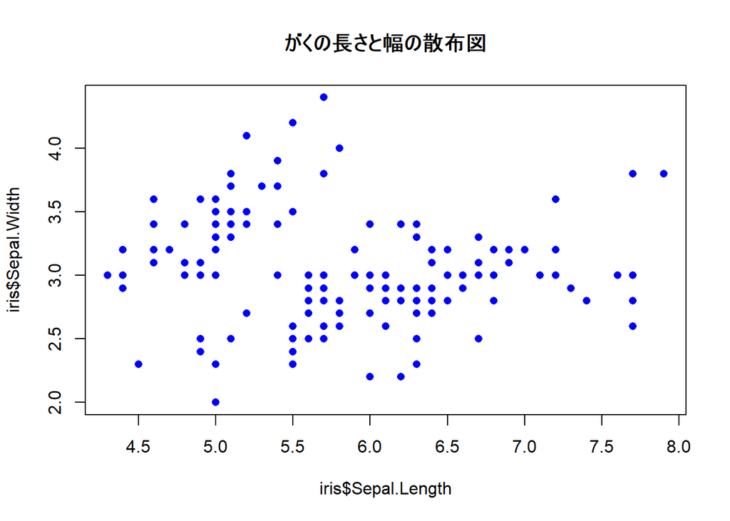

```r
plot(iris$Sepal.Length, iris$Sepal.Width,
     main = "がくの長さと幅の散布図", col = "blue", pch = 16)
```

✨ 関数： `boxplot()`

目的：グループごとのデータのばらつきを比較する「箱ひげ図」を描くよ

主要な引数：

- `formula` : `数値データ ~ グループ変数` の形式で指定します。
- `data` : 使うデータセット（データフレーム）。

### 1.4.2 箱ひげ図

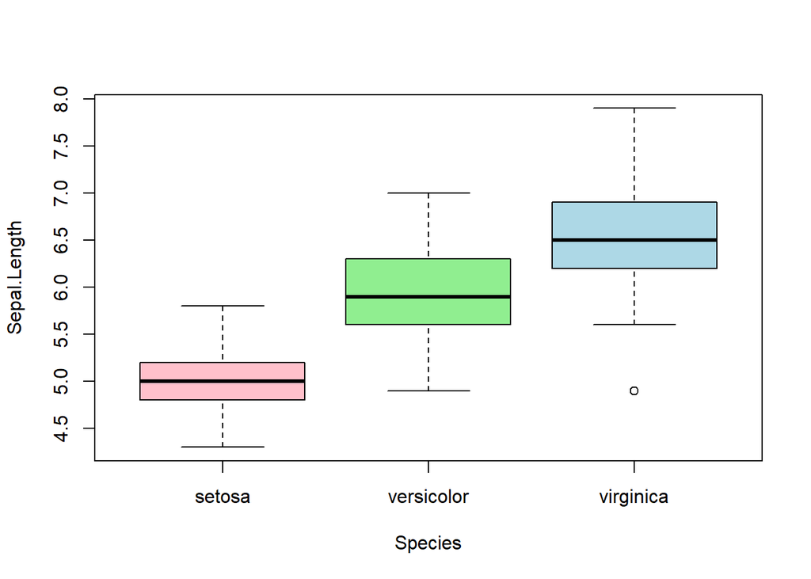

```r
boxplot(Sepal.Length ~ Species, data = iris, col = c("pink", "lightgreen", "lightblue"))
```

# 2 第2講 推測統計学の重要概念

ここではデータの分布や基本的な統計量について学びます。

## 2.1 図を描く（分布）

✨ 関数： `hist()`

目的：データの分布を見る「ヒストグラム」を描くよ

主要な引数：

- `x` : ヒストグラムにしたい数値データ。
- `breaks` : 棒の数を調整する目安の数値。

### 2.1.1 ヒストグラム

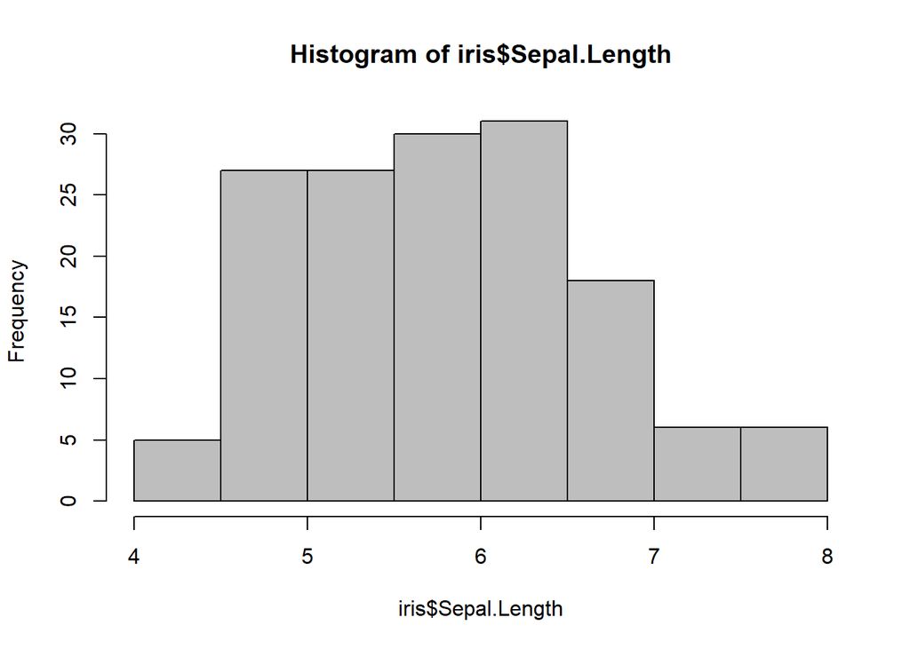

```r
hist(iris$Sepal.Length, breaks = 10, col = "gray")
```

✨ 関数： `curve()` と `dnorm()`

目的：関数の曲線（ここでは正規分布のカーブ）を描くよ

主要な引数：

- `expr` (curve内) : 描きたい関数。`dnorm(x)`は標準正規分布。
- `from, to` : X軸の描画範囲。
- `add` : TRUEにすると、既存のグラフの上に重ねて描きます。

### 2.1.2 正規分布と図に線を引く

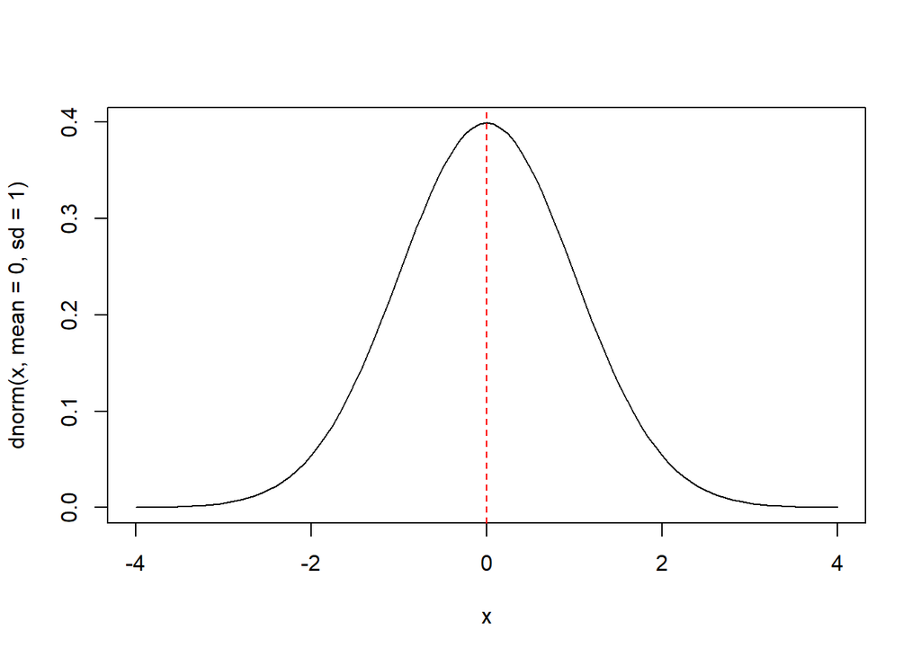

```r
curve(dnorm(x, mean = 0, sd = 1), from = -4, to = 4)
abline(v = 0, col = "red", lty = 2) # abline は直線を引く関数です
```

## 2.2 基本的な統計量

✨ 関数： `var()`, `cov()`, `cor()`

目的：データのばらつきや、関係性の強さを数値にするよ

主要な解説：

- `var(x)` : 分散（ばらつきの大きさ）を計算します。
- `cov(x, y)` : 共分散（2変数が一緒にどう変化するか）を計算します。
- `cor(x, y)` : 相関係数（-1から1の間で関係の強さ）を計算します。

```r
test_scores <- c(40, 50, 60, 60, 70, 80, 100)

median(test_scores) # 中央値
```

```
## [1] 60
```

```r
IQR(test_scores)    # 四分位範囲
```

```
## [1] 20
```

```r
var(test_scores)    # 分散
```

```
## [1] 395.2381
```

```r
cor(iris$Sepal.Length, iris$Sepal.Width) # 相関係数
```

```
## [1] -0.1175698
```

# 3 第3講 二群の平均値差の検定

## 3.1 t検定

✨ 関数： `t.test()`

目的：2つのグループの平均値に、意味のある差があるか（t検定）を調べるよ

主要な引数：

- `x, y` : 比較したい2つのグループのデータ。
- `var.equal` : TRUEで「等分散を仮定する」、FALSEで「仮定しない（ウェルチのt検定）」になります。

### 3.1.1 二群の平均値差の検定

```r
groupA <- iris$Sepal.Length[iris$Species == "setosa"]
groupB <- iris$Sepal.Length[iris$Species == "versicolor"]

t.test(groupA, groupB, var.equal = TRUE)
```

```
##
##  Two Sample t-test
##
## data:  groupA and groupB
## t = -10.521, df = 98, p-value < 2.2e-16
## alternative hypothesis: true difference in means is not equal to 0
## 95 percent confidence interval:
##  -1.1054165 -0.7545835
## sample estimates:
## mean of x mean of y
##     5.006     5.936
```

## 3.2 検出力

✨ 関数： `pwr.t.test()`

目的：サンプルサイズや検出力（差を見抜く力）を計算するよ

主要な引数：

- `d` : 効果量（差の大きさ）。
- `sig.level` : 有意水準（危険率）。通常は0.05。
- `power` : 検出力。通常は0.8を目標にします。

### 3.2.1 危険率・検出力を計算する

```r
pwr.t.test(n = 50, d = 0.5, sig.level = 0.05, type = "two.sample")
```

```
##
##      Two-sample t test power calculation
##
##               n = 50
##               d = 0.5
##       sig.level = 0.05
##           power = 0.6968934
##     alternative = two.sided
##
## NOTE: n is number in *each* group
```

## 3.3 実践：PCIbexデータの応用解析（日本人回答者限定）

✨ テーマ： `データフィルタリングと応用t検定`

目的：実際のPCIbexの結果ファイルから、特定の言語（lang2：日本人グループ）の回答者に限定して、2つの刺激に対する反応時間の差をウェルチのt検定で検証するよ

主要な解析ステップ：

- **対象者の特定**: `Element_Name == “language”` かつ `Value == “lang2”` の行から日本人参加者のID（MD5ハッシュ値）を抽出。
- **データの抽出**: 特定した参加者に絞り込み、刺激3 (stim1) と刺激11 (stim9) の `Start` / `End` イベント時間をフィルタリング。
- **反応時間の計算**: `pivot_wider()` を使って横型のデータ構造に変形し、

  ```
  End -
  Start
  ```

  （ms単位）を計算。
- **統計検定と視覚化**: `t.test()` によるWelchのt検定の実行と、`boxplot()` によるデータの可視化。

### 3.3.1 PCIbex結果ファイルの解析とT検定の実行

```r
# 1. ファイルの読み込みと基本整形（カンマ数が異なる行への対応）

library(dplyr)
library(tidyr)


# ディレクトリとファイルの読み込み設定 ----------------------------------------
# WindowsとMacの両方で文字化けを防ぐため、Encodingに "UTF-8" を明示的に指定します。

# [設定項目] 分析したいファイルが格納されているフォルダのパスとファイル名を設定してください
target_dir <- "path/to/your/directory" # 例: "C:/Users/Username/Documents" や "~/Documents"
file_name  <- "results.csv"             # PCIbexの結果ファイル名
```

```r
# 作業ディレクトリの変更
setwd(target_dir)

lines <- readLines(file_name, encoding = "UTF-8")
data_lines <- lines[!grepl("^#", lines)]

max_cols <- max(sapply(strsplit(data_lines, ","), length))
data_list <- lapply(strsplit(data_lines, ","), function(x) {
  length(x) <- max_cols
  return(x)
})
data <- as.data.frame(do.call(rbind, data_list), stringsAsFactors = FALSE)

colnames(data)[1:12] <- c("Reception_time", "MD5", "Controller", "Order_number",
                          "Inner_element", "Label", "Group", "Element_Type",
                          "Element_Name", "Parameter", "Value", "Event_Time")

# 2. 日本人参加者（lang2）の特定
target_lang <- "lang2"
lang_participants <- data %>%
  filter(Element_Name == "language",
         Parameter == "Selection",
         Value == target_lang) %>%
  pull(MD5) %>%
  unique()

# 3. 対象データの抽出と反応時間の計算
rt_data <- data %>%
  filter(MD5 %in% lang_participants,
         Order_number %in% c("3", "11"),
         Parameter == "_Trial_",
         Value %in% c("Start", "End")) %>%
  mutate(Event_Time = as.numeric(Event_Time)) %>%
  select(MD5, Order_number, Value, Event_Time) %>%
  pivot_wider(names_from = Value, values_from = Event_Time) %>%
  mutate(RT = End - Start,
         Condition = ifelse(Order_number == "3", "stim1", "stim9")) %>%
  drop_na(RT)

# 4. 記述統計の確認
cat("--- [lang2: 日本人限定] 基本統計量 ---\n")
```

```
## --- [lang2: 日本人限定] 基本統計量 ---
```

```r
aggregate(RT ~ Condition, data = rt_data,
          function(x) c(Mean = mean(x), SD = sd(x), N = length(x)))
```

```
##   Condition   RT.Mean     RT.SD      RT.N
## 1     stim1  3664.455  1979.335    11.000
## 2     stim9 12207.182 11945.720    11.000
```

```r
# 5. T検定（Welchのt検定）の実行
cat("\n--- [lang2: 日本人限定] T検定の結果 ---\n")
```

```
##
## --- [lang2: 日本人限定] T検定の結果 ---
```

```r
t.test(RT ~ Condition, data = rt_data, var.equal = FALSE)
```

```
##
##  Welch Two Sample t-test
##
## data:  RT by Condition
## t = -2.3399, df = 10.549, p-value = 0.0401
## alternative hypothesis: true difference in means between group stim1 and group stim9 is not equal to 0
## 95 percent confidence interval:
##  -16620.4002   -465.0544
## sample estimates:
## mean in group stim1 mean in group stim9
##            3664.455           12207.182
```

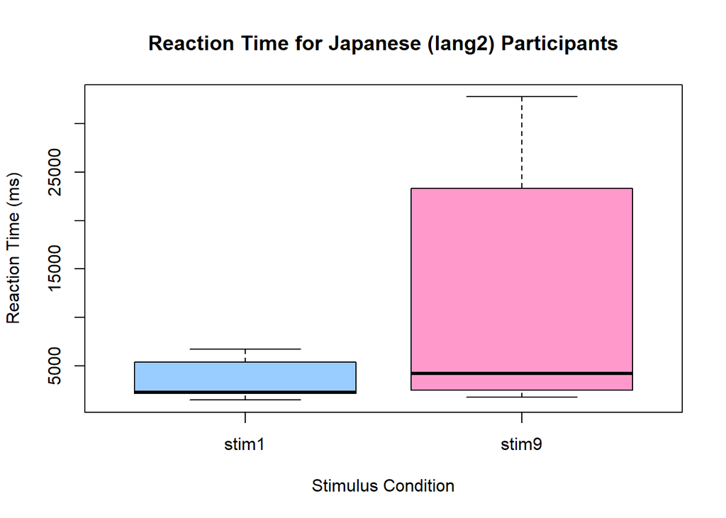

```r
# 6. 結果の可視化（Rmd内へのインライン描画）
boxplot(RT ~ Condition, data = rt_data,
        main = "Reaction Time for Japanese (lang2) Participants",
        xlab = "Stimulus Condition",
        ylab = "Reaction Time (ms)",
        col = c("#99ccff", "#ff99cc"))
```

# 4 第4講 単回帰分析

## 4.1 立体図

✨ 関数： `persp()`

目的：3次元の立体的な図（サーフェスプロット）を描くよ

主要な引数：

- `x, y, z` : X軸、Y軸の座標と、それに対応する高さZ。
- `theta, phi` : 図を眺める角度（横の回転と縦の角度）。

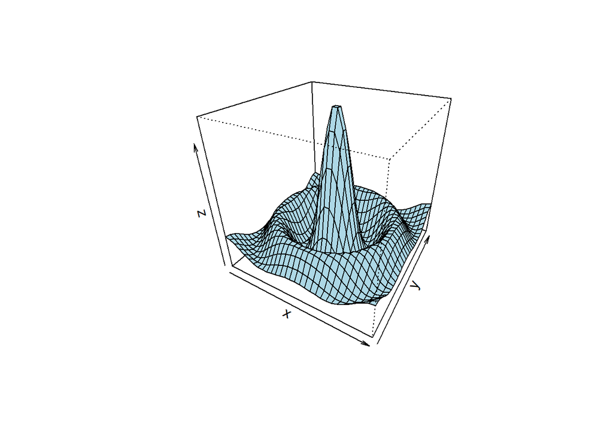

```r
x <- seq(-10, 10, length = 30); y <- x
f <- function(x, y) { r <- sqrt(x^2 + y^2); 10 * sin(r)/r }
z <- outer(x, y, f)
persp(x, y, z, theta = 30, phi = 30, col = "lightblue")
```

## 4.2 回帰分析の実行

✨ 関数： `lm()`

目的：直線でデータを予測する「線形回帰モデル」を作るよ

主要な引数：

- `formula` : `目的変数 ~ 説明変数` の形で予測式を書きます。
- `data` : 使うデータセット（データフレーム）。

```r
model <- lm(Sepal.Length ~ Sepal.Width, data = iris)
summary(model) # 結果の詳細を見る関数
```

```
##
## Call:
## lm(formula = Sepal.Length ~ Sepal.Width, data = iris)
##
## Residuals:
##     Min      1Q  Median      3Q     Max
## -1.5561 -0.6333 -0.1120  0.5579  2.2226
##
## Coefficients:
##             Estimate Std. Error t value Pr(>|t|)
## (Intercept)   6.5262     0.4789   13.63   <2e-16 ***
## Sepal.Width  -0.2234     0.1551   -1.44    0.152
## ---
## Signif. codes:  0 '***' 0.001 '**' 0.01 '*' 0.05 '.' 0.1 ' ' 1
##
## Residual standard error: 0.8251 on 148 degrees of freedom
## Multiple R-squared:  0.01382,    Adjusted R-squared:  0.007159
## F-statistic: 2.074 on 1 and 148 DF,  p-value: 0.1519
```

## 4.3 予測

✨ 関数： `predict()`

目的：作ったモデルを使って、新しいデータの予測値を計算するよ

主要な引数：

- `object` : `lm()` などで作ったモデルの変数。
- `newdata` : 予測したい新しいデータ（データフレーム形式）。
- `interval` : “confidence”（信頼区間）や “prediction”（予測区間）を指定します。

```r
new_flower <- data.frame(Sepal.Width = 3.5)

# 予測値の95%信頼区間
predict(model, newdata = new_flower, interval = "confidence")
```

```
##        fit      lwr      upr
## 1 5.744459 5.554388 5.934529
```